# Machine Learning - Course Project (Writeup)

Cristian Popescu

Thursday, October 23, 2014

### *Abstract*

*This report will focus on analysing and quantifying data on personal activities. Using devices such as Jawbone Up, Nike FuelBand, and Fitbit it is now possible to collect a large amount of data about personal activity relatively inexpensively. These type of devices are part of the quantified self movement  a group of enthusiasts who take measurements about themselves regularly to improve their health, to find patterns in their behavior, or because they are tech geeks. The analysis will use the data from accelerometers on the belt, forearm, arm, and dumbell of all the participants.*

### Introduction

The report starts by loading the data from `pml-training.csv` and `pml-testing.csv`. The `pml-training.csv` file will be used for training and testing, whereas the `pml-testing.csv` will be used for validation.

```r
myOriginalTraining = read.csv("pml-training.csv", header = TRUE)
myValidation = read.csv("pml-testing.csv", header = TRUE)
```

As a first observation, the data from `pml-training.csv`, does not contain only numerical/binery data. This is a good indication on what would be the methods that we can use for training our system. We would not be able to use `glm` or `lm` models.

```r
inTrain <- createDataPartition(y=myOriginalTraining$classe, p=0.95, list=FALSE)
myRestOfData <- myOriginalTraining[inTrain,]
myTraining1 <- myOriginalTraining[-inTrain,]
inTrain <- createDataPartition(y=myRestOfData$classe, p=0.25, list=FALSE)
myTesting1 <- myRestOfData[inTrain,]
inTrain <- createDataPartition(y=myRestOfData$classe, p=0.25, list=FALSE)
myTesting2 <- myRestOfData[inTrain,]
myTraining2 <- myRestOfData[-inTrain,]

#myTraining <- rbind(myTraining, myRestOfData[-inTrain,])
```

### Pre-Processing

Having the split now into training and testing, we will start to filter the original data and keep only the required predictors:

```r
accelIndex <- grep("^accel",names(myTraining1))
myListOfPredictors <- c(names(myTraining1)[accelIndex], "classe")
myTraining1 <- subset(myTraining1, select=myListOfPredictors)
myTesting1 <-  subset(myTesting1, select=myListOfPredictors)
myTraining2 <- subset(myTraining2, select=myListOfPredictors)
myTesting2 <-  subset(myTesting2, select=myListOfPredictors)
```

The required predictors are `accel_belt_x, accel_belt_y, accel_belt_z, accel_arm_x, accel_arm_y, accel_arm_z, accel_dumbbell_x, accel_dumbbell_y, accel_dumbbell_z, accel_forearm_x, accel_forearm_y, accel_forearm_z, classe`.

As a pre-processing, we will use the `PCA` method. Since, `PCA` method only is applicable for numeric data, we will have to *hide* the `classe` column. We will try to do a prediction using the new data:

```r
myNoClasseTraining <- subset(myTraining1, select=-c(classe))
preProc <- preProcess(myNoClasseTraining, method="pca", pcaComp=2)
myPrediction <- predict(preProc, myNoClasseTraining)
```

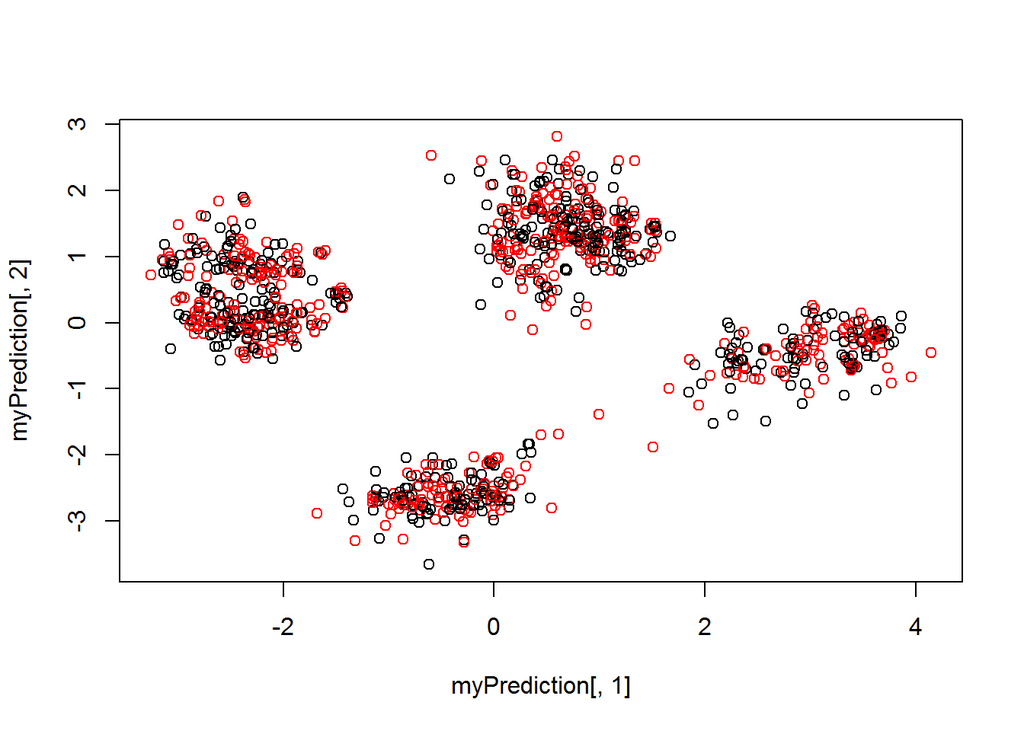

```r
plot(myPrediction[,1], myPrediction[,2], col=c("black","red"))
```

As we can see from the previous graph, we have 4 main groups (one group is actually splittled in two subgroups) identified on the screen, corresponding to the 4 main activities (belt, forearm, arm, and dumbell).

The `PCA` pre-processing method is not too conclusive because we are not going to use any linear method due to the nature of the data (non-numeric data). There is alot of overlapping and also distinction for each of the group for prediction and testing data.

### Building multiple models using Random Forest Trees

Next, we will build two models using Random Forest Trees (`rf`) and different training and testing sets and will fit a models that combines both predictions. We will use the cross-validation strategy to build our final model.

```r
#building models using Random Forest models
modelFitWithTrees1 <- train(classe ~ ., data=myTraining1, method="rf", trControl=trainControl(method="cv"), number=3)
modelFitWithTrees2 <- train(classe ~ ., data=myTraining2, method="rf", trControl=trainControl(method="cv"), number=3)
```

We will take a look at the summary of the models with both trainings and testing groups:

```r
print(modelFitWithTrees1)
```

```
## Random Forest
##
## 979 samples
##  12 predictor
##   5 classes: 'A', 'B', 'C', 'D', 'E'
##
## No pre-processing
## Resampling: Cross-Validated (10 fold)
##
## Summary of sample sizes: 881, 880, 882, 881, 881, 882, ...
##
## Resampling results across tuning parameters:
##
##   mtry  Accuracy  Kappa  Accuracy SD  Kappa SD
##    2    0.8       0.7    0.04         0.05
##    7    0.8       0.7    0.04         0.05
##   12    0.7       0.7    0.03         0.04
##
## Accuracy was used to select the optimal model using  the largest value.
## The final value used for the model was mtry = 2.
```

```r
print(modelFitWithTrees2)
```

```
## Random Forest
##
## 13981 samples
##    12 predictor
##     5 classes: 'A', 'B', 'C', 'D', 'E'
##
## No pre-processing
## Resampling: Cross-Validated (10 fold)
##
## Summary of sample sizes: 12583, 12584, 12584, 12583, 12582, 12582, ...
##
## Resampling results across tuning parameters:
##
##   mtry  Accuracy  Kappa  Accuracy SD  Kappa SD
##    2    0.9       0.9    0.005        0.006
##    7    0.9       0.9    0.006        0.008
##   12    0.9       0.9    0.004        0.005
##
## Accuracy was used to select the optimal model using  the largest value.
## The final value used for the model was mtry = 2.
```

Next, we will generate the two corresponing predictions and visualize them using:

```r
pred11 <- predict(modelFitWithTrees1, myTesting1)
pred22 <- predict(modelFitWithTrees2, myTesting2)
table(pred11, pred22)
```

```
##       pred22
## pred11    A    B    C    D    E
##      A 1106  119   80   60   17
##      B   24  617   59   27  150
##      C   85   74  638   85   50
##      D  108   30   64  563   27
##      E   20   33   12   21  593
```

We will be using now cross validation, by taking the previous prediction models and using them to the other testing sets (e.g. `pred1` against `myTesting2` and `pred2` against `myTesting1`):

```r
pred12 <- predict(modelFitWithTrees1, myTesting2)
pred21 <- predict(modelFitWithTrees2, myTesting1)
table(pred12, pred21)
```

```
##       pred21
## pred12    A    B    C    D    E
##      A 1102  130   79   62   10
##      B   19  629   68   29  152
##      C   80   74  610   92   39
##      D  107   44   57  569   30
##      E   14   26    9    6  625
```

We will fit a model that combines all previous predictions and traint it using `rf` (*Random Forest Trees*):

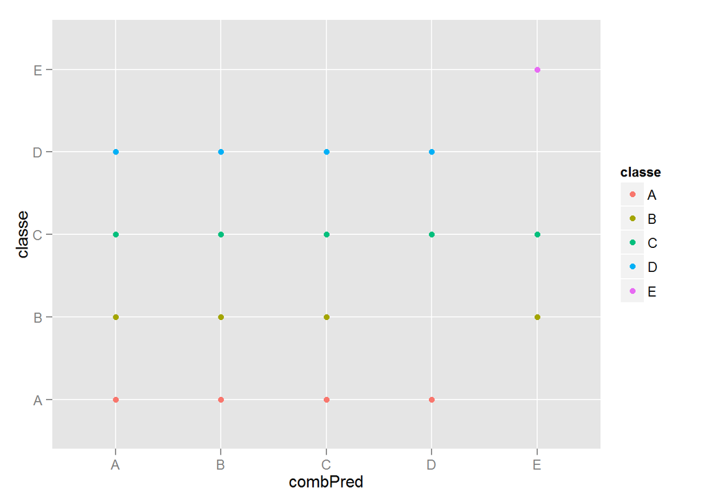

```r
predDF <- data.frame(pred11, pred22, pred12, pred21, classe=myTesting1$classe)
combModFit <- train(classe ~ ., data=predDF, method="rf", trControl=trainControl(method="cv"), number=3)
combPred <- predict(combModFit, predDF)
qplot(combPred, classe, colour=classe, data=predDF)
```

Lets take a look at the model found:

```r
print(combModFit)
```

```
## Random Forest
##
## 4662 samples
##    4 predictor
##    5 classes: 'A', 'B', 'C', 'D', 'E'
##
## No pre-processing
## Resampling: Cross-Validated (10 fold)
##
## Summary of sample sizes: 4195, 4197, 4196, 4194, 4197, 4196, ...
##
## Resampling results across tuning parameters:
##
##   mtry  Accuracy  Kappa  Accuracy SD  Kappa SD
##    2    1         1      0.004        0.005
##    9    1         1      0.004        0.005
##   16    1         1      0.004        0.005
##
## Accuracy was used to select the optimal model using  the largest value.
## The final value used for the model was mtry = 9.
```

Next, we will calculate the `confusionMatrix` for all of the previous models:

```r
confMatrix11 <- confusionMatrix(pred11, myTesting1$classe)
confMatrix12 <- confusionMatrix(pred12, myTesting2$classe)
confMatrix21 <- confusionMatrix(pred21, myTesting1$classe)
confMatrix22 <- confusionMatrix(pred22, myTesting2$classe)
confMatrixComb <- confusionMatrix(combPred, predDF$classe)
```

The estimation of the error is (for each of the predictions): 1. for model `modelFitWithTrees1` with testing `myTesting1`: `0.2325`; 2. for model `modelFitWithTrees1` with testing `myTesting2`: `0.236`; 3. for model `modelFitWithTrees2` with testing `myTesting1`: `0.0122`; 4. for model `modelFitWithTrees2` with testing `myTesting2`: `0.0487`; 5. for combined model `combModFit` with testing the combined prediction (of the previous models) `predDF`: `0.0099`;

### Validation with `pml-testing.csv`

Based on the previous models, the best result on accurancy is from `combPred` model (`Accuracy :` `0.9901`). We will use the combined model in order to apply the validation data from `pml-testing.csv` file.

```r
predValidation <- predict(combModFit, myValidation)
```

Next, we will visualize the computed validation:

```r
predValidationOccurances <-count(predValidation)
print(predValidationOccurances)
```

[output not shown]

[figure not shown]

```r
qplot(predValidationOccurances$x, predValidationOccurances$freq, colour = predValidationOccurances$x)
```